# Maintenance cost reduction through predictive techniques

### BACKGROUND

A company has a fleet of devices transmitting daily telemetry readings. They would like to create a predictive maintenance solution to proactively identify when maintenance should be performed. This approach promises cost savings over routine or time-based preventive maintenance, because tasks are performed only when warranted.

### GOAL

You are tasked with building a predictive model using machine learning to predict the probability of a device failure. When building this model, be sure to minimize false positives and false negatives. The column you are trying to predict is called failure with binary value 0 for non-failure and 1 for failure.

### APPROACH

There are several ways to formulate a predictive maintenance problem:

1. Binary classification: define a window leading up to failure where the probability is predicted
2. Multi-class classification: define buckets of "time to failure" and predict those classes directly
3. Regression: define "time to failure" as a continuous variable and predict that directly
4. Unsupervised: use independent variables to identify anomalous behaviour which could indicate imminent failure

I opted for formulation #1 with a 30 day failure window because the goal specifies that probability of device failure should be predicted.

In a real world setting, the correct approach would depend on the business case for the model.  
Questions I'd explore are:

- How much advance notice is needed to service devices before failure occurs?
- What is the cost of a false positive? What is the cost of a false negative?
- How do maintenance decision makers prefer to view risk of a failure? How much justification is needed to make a decision?

### RESULTS

Random forest was able to give extremely promising results (F1=0.98), producing a few false negatives and no false positives. Catboost (F1=0.83) was the runner up while logistic regression (F1=0.07) was largely ineffective. Metrics 6, 1, and 5 seem to be the most predictive of failure.

### RECOMMENDATION

I would propose the random forest model to business stakeholders for use in predicting maintenance work. I would also recommend using an interpretability framework like SHAP to understand which of the sensors was most predictive of the upcoming failure, so service technicians have some insight into where the issues may lie.

While this RF model is being prototyped, I'd explore other methods or more intensive feature engineering techniques to arrive at a more robust model that may generalize better to unseen data. I would also set up a monitoring framework to ensure this model doesn't suffer from concept drift over time, and consider implementing a retraining cadence as we collect more telemetry data. This is a fairly small dataset, and we only evaluated on a test set of 26 failed devices. I would be cautious about using this model in a production setting to make business decisions until we do more exhaustive cross validtion or evaluate the model on more unseen device failures.

```python
import pandas as pd
import numpy as np
import seaborn as sb
import tsfresh as ts
%matplotlib inline
from IPython.core.interactiveshell import InteractiveShell
InteractiveShell.ast_node_interactivity = "all"
from IPython.display import display, HTML
display(HTML(data="""<style> div#notebook-container{width:95%;}</style>"""))
import warnings
warnings.filterwarnings("ignore")

from sklearn.linear_model import LogisticRegression, SGDClassifier
from sklearn.ensemble import RandomForestClassifier
from sklearn.preprocessing import StandardScaler
from sklearn.pipeline import Pipeline
from sklearn.model_selection import GridSearchCV
from sklearn.metrics import accuracy_score, confusion_matrix, classification_report, precision_recall_curve, plot_precision_recall_curve, f1_score
from imblearn.over_sampling import SMOTE
import phik
```

## Exploratory Analysis

Check for missing data, class imbalance, predictive signal, and identify ideas for feature engineering

```python
df = pd.read_csv('predictive_maintenance.csv')
print(df.shape)
df.sample(3)
```

```
(124494, 12)
```

|  | date | device | failure | metric1 | metric2 | metric3 | metric4 | metric5 | metric6 | metric7 | metric8 | metric9 |
| --- | --- | --- | --- | --- | --- | --- | --- | --- | --- | --- | --- | --- |
| 80585 | 5/11/15 | Z1F18YST | 0 | 98037776 | 0 | 0 | 0 | 8 | 231275 | 0 | 0 | 0 |
| 78242 | 5/6/15 | S1F0RS3B | 0 | 104190272 | 0 | 0 | 0 | 7 | 275164 | 0 | 0 | 0 |
| 95075 | 6/22/15 | S1F0GRB1 | 0 | 185907584 | 0 | 0 | 0 | 67 | 251116 | 0 | 0 | 0 |

```python
# Data does not contain any null values, all metrics are integers
df.info()
```

```
<class 'pandas.core.frame.DataFrame'>
RangeIndex: 124494 entries, 0 to 124493
Data columns (total 12 columns):
 #   Column   Non-Null Count   Dtype
---  ------   --------------   -----
 0   date     124494 non-null  object
 1   device   124494 non-null  object
 2   failure  124494 non-null  int64
 3   metric1  124494 non-null  int64
 4   metric2  124494 non-null  int64
 5   metric3  124494 non-null  int64
 6   metric4  124494 non-null  int64
 7   metric5  124494 non-null  int64
 8   metric6  124494 non-null  int64
 9   metric7  124494 non-null  int64
 10  metric8  124494 non-null  int64
 11  metric9  124494 non-null  int64
dtypes: int64(10), object(2)
memory usage: 11.4+ MB
```

```python
# Metric 7 & 8 have identical distributions, will drop one to save resources & avoid multicolinearity
df.describe()
```

|  | failure | metric1 | metric2 | metric3 | metric4 | metric5 | metric6 | metric7 | metric8 | metric9 |
| --- | --- | --- | --- | --- | --- | --- | --- | --- | --- | --- |
| count | 124494.000000 | 1.244940e+05 | 124494.000000 | 124494.000000 | 124494.000000 | 124494.000000 | 124494.000000 | 124494.000000 | 124494.000000 | 124494.000000 |
| mean | 0.000851 | 1.223881e+08 | 159.484762 | 9.940455 | 1.741120 | 14.222669 | 260172.657726 | 0.292528 | 0.292528 | 12.451524 |
| std | 0.029167 | 7.045933e+07 | 2179.657730 | 185.747321 | 22.908507 | 15.943028 | 99151.078547 | 7.436924 | 7.436924 | 191.425623 |
| min | 0.000000 | 0.000000e+00 | 0.000000 | 0.000000 | 0.000000 | 1.000000 | 8.000000 | 0.000000 | 0.000000 | 0.000000 |
| 25% | 0.000000 | 6.128476e+07 | 0.000000 | 0.000000 | 0.000000 | 8.000000 | 221452.000000 | 0.000000 | 0.000000 | 0.000000 |
| 50% | 0.000000 | 1.227974e+08 | 0.000000 | 0.000000 | 0.000000 | 10.000000 | 249799.500000 | 0.000000 | 0.000000 | 0.000000 |
| 75% | 0.000000 | 1.833096e+08 | 0.000000 | 0.000000 | 0.000000 | 12.000000 | 310266.000000 | 0.000000 | 0.000000 | 0.000000 |
| max | 1.000000 | 2.441405e+08 | 64968.000000 | 24929.000000 | 1666.000000 | 98.000000 | 689161.000000 | 832.000000 | 832.000000 | 18701.000000 |

```
[2015]
```

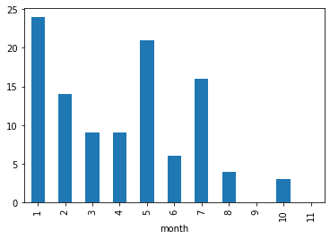

```python
# We observe most of the failures happen earlier in the time series
viz_df = df.copy()
viz_df['date'] = pd.to_datetime(viz_df.date)
viz_df['month'] = viz_df.date.dt.month
viz_df['year'] = viz_df.date.dt.year
print(viz_df.year.unique()) # Ensure we only have 1 year of observations
viz_df.groupby('month').failure.sum().plot(kind='bar')
```

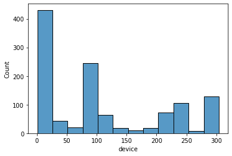

```python
# We are working with unequal length time series, possibly with gaps in between. Will need to consider this during feature extraction.
sb.histplot(df.device.value_counts())
```

```python
# Subset the devices with a low sample count and inspect features
failed_devices = df.query("failure == 1")
device_counts = df.device.value_counts()
viz_devices = list(set(device_counts[device_counts < 50].index) & set(failed_devices.device))
```

```
array([<AxesSubplot:xlabel='date'>, <AxesSubplot:xlabel='date'>,
       <AxesSubplot:xlabel='date'>, <AxesSubplot:xlabel='date'>,
       <AxesSubplot:xlabel='date'>, <AxesSubplot:xlabel='date'>,
       <AxesSubplot:xlabel='date'>, <AxesSubplot:xlabel='date'>,
       <AxesSubplot:xlabel='date'>, <AxesSubplot:xlabel='date'>],
      dtype=object)
```

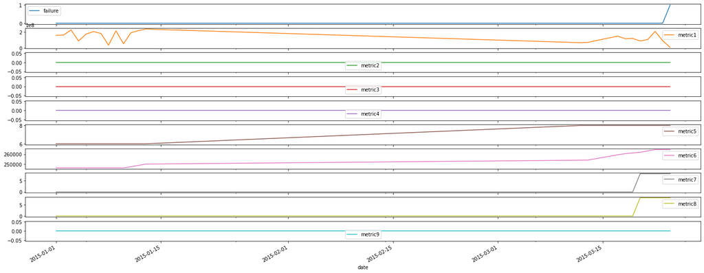

```python
# Plot time series lines for single devices to find clues for feature engineering
# It seems that several metrics tend to spike in the weeks leading up to a failure
viz_dev = viz_devices[0]
df.query("device == @viz_dev").plot(kind='line', x='date', figsize=(25, 15), subplots=True)
```

```python
# Inspect discontinuity in time series - a gap is observed for this device from Jan to Mar
df.query("device == @viz_dev").date.unique()
```

```
array(['2015-01-01T00:00:00.000000000', '2015-01-02T00:00:00.000000000',
       '2015-01-03T00:00:00.000000000', '2015-01-04T00:00:00.000000000',
       '2015-01-05T00:00:00.000000000', '2015-01-06T00:00:00.000000000',
       '2015-01-07T00:00:00.000000000', '2015-01-08T00:00:00.000000000',
       '2015-01-09T00:00:00.000000000', '2015-01-10T00:00:00.000000000',
       '2015-01-11T00:00:00.000000000', '2015-01-12T00:00:00.000000000',
       '2015-01-13T00:00:00.000000000', '2015-03-12T00:00:00.000000000',
       '2015-03-13T00:00:00.000000000', '2015-03-14T00:00:00.000000000',
       '2015-03-15T00:00:00.000000000', '2015-03-16T00:00:00.000000000',
       '2015-03-17T00:00:00.000000000', '2015-03-18T00:00:00.000000000',
       '2015-03-19T00:00:00.000000000', '2015-03-20T00:00:00.000000000',
       '2015-03-21T00:00:00.000000000', '2015-03-22T00:00:00.000000000',
       '2015-03-23T00:00:00.000000000', '2015-03-24T00:00:00.000000000'],
      dtype='datetime64[ns]')
```

## Preprocessing

Fix issues like time series gaps, extraneous records, & class imbalance

```python
# Resample time series and ensure forward filling is performed correctly
df['date'] = pd.to_datetime(df.date)
features = df.drop(columns='metric8').sort_values(['device', 'date']).set_index(['date']).sort_index()
features = features.groupby('device').resample('d').mean().ffill().reset_index()
features.query("device == @viz_dev").iloc[8:15]
```

|  | device | date | failure | metric1 | metric2 | metric3 | metric4 | metric5 | metric6 | metric7 | metric9 |
| --- | --- | --- | --- | --- | --- | --- | --- | --- | --- | --- | --- |
| 82322 | W1F0Z4EA | 2015-01-09 | 0.0 | 213722944.0 | 0.0 | 0.0 | 0.0 | 6.0 | 246340.0 | 0.0 | 0.0 |
| 82323 | W1F0Z4EA | 2015-01-10 | 0.0 | 52768584.0 | 0.0 | 0.0 | 0.0 | 6.0 | 246340.0 | 0.0 | 0.0 |
| 82324 | W1F0Z4EA | 2015-01-11 | 0.0 | 190176424.0 | 0.0 | 0.0 | 0.0 | 6.0 | 247451.0 | 0.0 | 0.0 |
| 82325 | W1F0Z4EA | 2015-01-12 | 0.0 | 216593552.0 | 0.0 | 0.0 | 0.0 | 6.0 | 248782.0 | 0.0 | 0.0 |
| 82326 | W1F0Z4EA | 2015-01-13 | 0.0 | 235772032.0 | 0.0 | 0.0 | 0.0 | 6.0 | 250136.0 | 0.0 | 0.0 |
| 82327 | W1F0Z4EA | 2015-01-14 | 0.0 | 235772032.0 | 0.0 | 0.0 | 0.0 | 6.0 | 250136.0 | 0.0 | 0.0 |
| 82328 | W1F0Z4EA | 2015-01-15 | 0.0 | 235772032.0 | 0.0 | 0.0 | 0.0 | 6.0 | 250136.0 | 0.0 | 0.0 |

```python
# Define a time to failure column so we can generate a target variable within a window of failure time (30 days)
fail_dates = df.query("failure == 1")[['device', 'date']].rename(columns={'date': 'fail_date'})
features = features.merge(fail_dates, how='left', on='device')
features['time_to_failure'] = features.fail_date - features.date
features['fail_in_30d'] = (features.time_to_failure.dt.days <= 30).astype(int)
features[features.fail_date.notnull()].head()
```

|  | device | date | failure | metric1 | metric2 | metric3 | metric4 | metric5 | metric6 | metric7 | metric9 | fail_date | time_to_failure | fail_in_30d |
| --- | --- | --- | --- | --- | --- | --- | --- | --- | --- | --- | --- | --- | --- | --- |
| 420 | S1F023H2 | 2015-01-01 | 0.0 | 141503600.0 | 0.0 | 0.0 | 1.0 | 19.0 | 494462.0 | 16.0 | 3.0 | 2015-01-19 | 18 days | 1 |
| 421 | S1F023H2 | 2015-01-02 | 0.0 | 161679800.0 | 0.0 | 0.0 | 1.0 | 19.0 | 495730.0 | 16.0 | 3.0 | 2015-01-19 | 17 days | 1 |
| 422 | S1F023H2 | 2015-01-03 | 0.0 | 182358672.0 | 0.0 | 0.0 | 1.0 | 19.0 | 496974.0 | 16.0 | 3.0 | 2015-01-19 | 16 days | 1 |
| 423 | S1F023H2 | 2015-01-04 | 0.0 | 204752808.0 | 0.0 | 0.0 | 1.0 | 19.0 | 497559.0 | 16.0 | 3.0 | 2015-01-19 | 15 days | 1 |
| 424 | S1F023H2 | 2015-01-05 | 0.0 | 226982888.0 | 0.0 | 0.0 | 1.0 | 19.0 | 498753.0 | 16.0 | 3.0 | 2015-01-19 | 14 days | 1 |

```python
# Inspect data for records that occur after failure
features.query("date > fail_date").shape
```

```
(47, 14)
```

```python
# We want to clean these up so they don't add noise to our training
features = features[features.fail_date.isnull() | (features.date <= features.fail_date)]
features.shape
```

```
(131433, 14)
```

## Feature engineering

Based on the sensor spikes we saw leading up to failures, let's use differencing and rolling window features to give the model more signal

```python
# Generate difference features - validate hypotehsis that most failures happen after a spike/dip in the metrics
metric_features = features.drop(columns=['failure', 'fail_date', 'time_to_failure', 'fail_in_30d', 'date'])
diff_features = metric_features.groupby('device').diff().fillna(0)
diff_features.columns = [x + '_diff' for x in diff_features.columns]
features = features.merge(diff_features, left_index=True, right_index=True)
features.head(2)
```

|  | device | date | failure | metric1 | metric2 | metric3 | metric4 | metric5 | metric6 | metric7 | ... | time_to_failure | fail_in_30d | metric1_diff | metric2_diff | metric3_diff | metric4_diff | metric5_diff | metric6_diff | metric7_diff | metric9_diff |
| --- | --- | --- | --- | --- | --- | --- | --- | --- | --- | --- | --- | --- | --- | --- | --- | --- | --- | --- | --- | --- | --- |
| 0 | S1F01085 | 2015-01-01 | 0.0 | 215630672.0 | 56.0 | 0.0 | 52.0 | 6.0 | 407438.0 | 0.0 | ... | NaT | 0 | 0.0 | 0.0 | 0.0 | 0.0 | 0.0 | 0.0 | 0.0 | 0.0 |
| 1 | S1F01085 | 2015-01-02 | 0.0 | 1650864.0 | 56.0 | 0.0 | 52.0 | 6.0 | 407438.0 | 0.0 | ... | NaT | 0 | -213979808.0 | 0.0 | 0.0 | 0.0 | 0.0 | 0.0 | 0.0 | 0.0 |

2 rows × 22 columns

```python
# Look at distributions of time to failure for the non-zero diff features to understand what size rolling windows should be
metrics = ['metric1_diff', 'metric2_diff', 'metric3_diff', 'metric4_diff', 'metric5_diff', 'metric6_diff', 'metric7_diff', 'metric9_diff']
diff_stats = []
for metric in metrics:
    diff_idx = diff_features.query(f'{metric} != 0').index
    stats = features.loc[diff_idx, 'time_to_failure'].describe()
    stats['feature'] = metric
    diff_stats.append(stats)
diff_stats = pd.concat(diff_stats, axis=1)
diff_stats
```

|  | time_to_failure | time_to_failure | time_to_failure | time_to_failure | time_to_failure | time_to_failure | time_to_failure | time_to_failure |
| --- | --- | --- | --- | --- | --- | --- | --- | --- |
| count | 10558 | 404 | 1 | 123 | 55 | 3922 | 71 | 13 |
| mean | 79 days 13:57:50.430005683 | 36 days 08:29:42.178217822 | 90 days 00:00:00 | 13 days 19:07:19.024390244 | 57 days 06:58:54.545454545 | 82 days 12:57:16.613972463 | 11 days 08:27:02.535211267 | 50 days 05:32:18.461538461 |
| std | 60 days 00:32:57.648054957 | 45 days 20:49:53.783256946 | NaT | 30 days 11:21:33.504929639 | 71 days 13:35:24.290026875 | 65 days 14:25:28.633024544 | 21 days 18:03:41.936523278 | 65 days 12:06:41.629905656 |
| min | 0 days 00:00:00 | 0 days 00:00:00 | 90 days 00:00:00 | 0 days 00:00:00 | 0 days 00:00:00 | 0 days 00:00:00 | 0 days 00:00:00 | 1 days 00:00:00 |
| 25% | 29 days 00:00:00 | 5 days 18:00:00 | 90 days 00:00:00 | 1 days 00:00:00 | 7 days 00:00:00 | 23 days 00:00:00 | 1 days 00:00:00 | 2 days 00:00:00 |
| 50% | 69 days 00:00:00 | 16 days 12:00:00 | 90 days 00:00:00 | 3 days 00:00:00 | 25 days 00:00:00 | 71 days 00:00:00 | 3 days 00:00:00 | 16 days 00:00:00 |
| 75% | 119 days 00:00:00 | 51 days 06:00:00 | 90 days 00:00:00 | 7 days 12:00:00 | 79 days 12:00:00 | 125 days 00:00:00 | 9 days 12:00:00 | 109 days 00:00:00 |
| max | 297 days 00:00:00 | 206 days 00:00:00 | 90 days 00:00:00 | 187 days 00:00:00 | 277 days 00:00:00 | 297 days 00:00:00 | 107 days 00:00:00 | 168 days 00:00:00 |
| feature | metric1_diff | metric2_diff | metric3_diff | metric4_diff | metric5_diff | metric6_diff | metric7_diff | metric9_diff |

```python
# Drop the metric3 diff feature because it seems to be mostly flat & only shows one spike
diff_features.drop(columns='metric3_diff', inplace=True)
features.drop(columns='metric3_diff', inplace=True)
```

```python
# Generate rolling std dev features - use rolling window sizes learned from above distributions
# 50th & 75th quantiles should capture most metric spikes that correlate with failures
quantile = '50%'
rolling_features = []
for metric in diff_features.columns:
    window_size = diff_stats.T.query("feature == @metric")[quantile].dt.days.values[0]
    rolling_feature = features[['device'] + diff_features.columns.tolist()].groupby('device')[metric].rolling(window_size, min_periods=1).std().fillna(0)
    rolling_feature.name = rolling_feature.name + '_roll_std_' + str(window_size)
    rolling_features.append(rolling_feature)

rolling_features = pd.concat(rolling_features, axis=1)
features = features.reset_index(drop=True)
rolling_features = rolling_features.reset_index(drop=True)
features = features.merge(rolling_features, left_index=True, right_index=True)
```

```python
quantile = '75%'
rolling_features = []
for metric in diff_features.columns:
    window_size = diff_stats.T.query("feature == @metric")[quantile].dt.days.values[0]
    rolling_feature = features[['device'] + diff_features.columns.tolist()].groupby('device')[metric].rolling(window_size, min_periods=1).std().fillna(0)
    rolling_feature.name = rolling_feature.name + '_roll_std_' + str(window_size)
    rolling_features.append(rolling_feature)

rolling_features = pd.concat(rolling_features, axis=1)
features = features.reset_index(drop=True)
rolling_features = rolling_features.reset_index(drop=True)
features = features.merge(rolling_features, left_index=True, right_index=True)

features.describe()
```

|  | failure | metric1 | metric2 | metric3 | metric4 | metric5 | metric6 | metric7 | metric9 | time_to_failure | ... | metric6_diff_roll_std_71 | metric7_diff_roll_std_3 | metric9_diff_roll_std_16 | metric1_diff_roll_std_119 | metric2_diff_roll_std_51 | metric4_diff_roll_std_7 | metric5_diff_roll_std_79 | metric6_diff_roll_std_125 | metric7_diff_roll_std_9 | metric9_diff_roll_std_109 |
| --- | --- | --- | --- | --- | --- | --- | --- | --- | --- | --- | --- | --- | --- | --- | --- | --- | --- | --- | --- | --- | --- |
| count | 131433.000000 | 1.314330e+05 | 131433.000000 | 131433.000000 | 131433.000000 | 131433.000000 | 131433.000000 | 131433.000000 | 131433.000000 | 11438 | ... | 131433.000000 | 131433.000000 | 131433.000000 | 1.314330e+05 | 131433.000000 | 131433.000000 | 131433.000000 | 131433.000000 | 131433.000000 | 131433.000000 |
| mean | 0.000806 | 1.226462e+08 | 154.010941 | 10.449453 | 1.559532 | 14.010431 | 258680.476570 | 0.278910 | 13.331774 | 78 days 14:23:23.741912922 | ... | 407.003265 | 0.042617 | 0.003977 | 8.501694e+07 | 11.779676 | 0.085703 | 0.026509 | 448.767165 | 0.041197 | 0.007562 |
| std | 0.028388 | 7.046408e+07 | 2138.346581 | 187.958535 | 21.054097 | 15.599688 | 98830.330176 | 7.247649 | 193.811982 | 59 days 02:50:52.641932699 | ... | 279.444400 | 2.594138 | 0.100898 | 2.354433e+07 | 412.895717 | 5.128191 | 0.073924 | 255.353535 | 1.713718 | 0.102822 |
| min | 0.000000 | 0.000000e+00 | 0.000000 | 0.000000 | 0.000000 | 1.000000 | 8.000000 | 0.000000 | 0.000000 | 0 days 00:00:00 | ... | 0.000000 | 0.000000 | 0.000000 | 0.000000e+00 | 0.000000 | 0.000000 | 0.000000 | 0.000000 | 0.000000 | 0.000000 |
| 25% | 0.000000 | 6.162395e+07 | 0.000000 | 0.000000 | 0.000000 | 8.000000 | 220473.000000 | 0.000000 | 0.000000 | 29 days 00:00:00 | ... | 204.881358 | 0.000000 | 0.000000 | 7.898164e+07 | 0.000000 | 0.000000 | 0.000000 | 321.109744 | 0.000000 | 0.000000 |
| 50% | 0.000000 | 1.229709e+08 | 0.000000 | 0.000000 | 0.000000 | 10.000000 | 249255.000000 | 0.000000 | 0.000000 | 68 days 00:00:00 | ... | 457.350660 | 0.000000 | 0.000000 | 9.003231e+07 | 0.000000 | 0.000000 | 0.000000 | 497.340620 | 0.000000 | 0.000000 |
| 75% | 0.000000 | 1.833823e+08 | 0.000000 | 0.000000 | 0.000000 | 12.000000 | 309464.000000 | 0.000000 | 0.000000 | 117 days 00:00:00 | ... | 588.047659 | 0.000000 | 0.000000 | 9.878814e+07 | 0.000000 | 0.000000 | 0.000000 | 591.607596 | 0.000000 | 0.000000 |
| max | 1.000000 | 2.441405e+08 | 64968.000000 | 24929.000000 | 1666.000000 | 98.000000 | 689161.000000 | 832.000000 | 18701.000000 | 298 days 00:00:00 | ... | 2709.249884 | 480.355424 | 15.264338 | 2.053894e+08 | 44185.688543 | 629.688812 | 1.114172 | 2709.249884 | 277.333333 | 15.264338 |

8 rows × 32 columns

```python
# Pearson correlation is not showing strong linear relationships between independent variables and our target, so I'm not confident that linear methods will perform well
features.corr().fail_in_30d.sort_values(ascending=False)
```

```
fail_in_30d                  1.000000
failure                      0.185762
metric4                      0.103763
metric7                      0.089621
metric7_diff_roll_std_9      0.078746
metric4_diff_roll_std_7      0.076208
metric2                      0.074519
metric2_diff_roll_std_16     0.072650
metric2_diff_roll_std_51     0.069308
metric7_diff_roll_std_3      0.063716
metric4_diff_roll_std_3      0.058530
metric5_diff_roll_std_79     0.048939
metric5_diff_roll_std_25     0.048805
metric7_diff                 0.045803
metric4_diff                 0.045119
metric2_diff                 0.032473
metric5_diff                 0.020084
metric5                      0.013853
metric9_diff_roll_std_16     0.010065
metric6_diff                 0.008669
metric9                      0.007941
metric9_diff                 0.005797
metric9_diff_roll_std_109    0.002674
metric1_diff                -0.000024
metric1                     -0.001404
metric6                     -0.004379
metric3                     -0.005038
metric6_diff_roll_std_125   -0.006274
metric1_diff_roll_std_119   -0.021241
metric6_diff_roll_std_71    -0.023480
metric1_diff_roll_std_69    -0.024229
Name: fail_in_30d, dtype: float64
```